# Synthetic Data Generation: SDSS 2022 Short Course

Joshua Snoke

2022-06-07

## I-CEM 1901 Scottish Census Data Example

For this code, we will use a portion of the 1901 Scottish Census. Thanks to the SYLLS and the synthpop team for preparing and sharing this file, which can be found at: https://synthpop.org.uk/resources.html.

NOTE: synthpop does not work well with the tidyverse, so I will be using traditional R instead.

```r
load('i-cem.rdata')
## let's just work with a subset of the variables
icem_data = data[, c('sex',
                     'age',
                     'mar_stat',
                     'disability',
                     'employ',
                     'ctry_bth',
                     'hsize',
                     'totrooms',
                     'pperroom')]
rm(data)

head(icem_data,
     n = 10)
```

```
##      sex age mar_stat disability employ ctry_bth hsize totrooms pperroom
## 1102   M  47  Married       None      W      ENG     4        2     2.00
## 1106   F  81  Widowed       None             SCT     5        2     2.50
## 1111   M  59  Married       None      W      SCT     1        2     0.50
## 1145   F  70   Single       None             SCT     1        2     0.50
## 1146   M  51  Widowed       None      W      SCT     4        2     2.00
## 1150   M  51  Married       None      W      SCT     4        2     2.00
## 1194   M  32  Married       None             SCT     4        2     2.00
## 1198   F  63  Widowed       None             SCT     2        1     2.00
## 1200   M  60   Single       None      E      SCT     3        4     0.75
## 1262   M  37  Widowed       None      W      SCT     2        2     1.00
```

## Simple Synthesis Model

First, let’s produce a simple synthetic data set for just a few demographic variables in the data.

```r
simple_icem = icem_data[icem_data$mar_stat != 'Divorced',
                        c('sex',
                          'age',
                          'mar_stat',
                          'employ')]
## Here is the syntax
synthetic_icem = syn(simple_icem,
                     ## Here we will tell it to use sequential parametric models
                     method = 'parametric')
```

```
## Synthesis
## -----------
##  sex age mar_stat employ
```

```r
## A few outputs of interest
synthetic_icem$method
```

```
##        sex        age   mar_stat     employ
##   "sample" "normrank"  "polyreg"  "polyreg"
```

```r
synthetic_icem$visit.sequence
```

```
##      sex      age mar_stat   employ
##        1        2        3        4
```

```r
synthetic_icem$predictor.matrix
```

```
##          sex age mar_stat employ
## sex        0   0        0      0
## age        1   0        0      0
## mar_stat   1   1        0      0
## employ     1   1        1      0
```

```r
## We can change the visit.sequence (order of synthesized variables)
synthetic_icem_2 = syn(simple_icem,
                       method = 'parametric',
                       ## Here we change the order of synthesis
                       visit.sequence = c('employ', 'age', 'mar_stat', 'sex'))
```

```
## Synthesis
## -----------
##  employ age mar_stat sex
```

```r
## A few outputs of interest
synthetic_icem_2$method
```

```
##        sex        age   mar_stat     employ
##   "logreg" "normrank"  "polyreg"   "sample"
```

```r
synthetic_icem_2$visit.sequence
```

```
##   employ      age mar_stat      sex
##        4        2        3        1
```

```r
synthetic_icem_2$predictor.matrix
```

```
##          sex age mar_stat employ
## sex        0   1        1      1
## age        0   0        0      1
## mar_stat   0   1        0      1
## employ     0   0        0      0
```

```r
## We can use non-parametric CART models instead of GLMs
synthetic_icem_3 = syn(simple_icem,
                       ## Here we will tell it to use sequential CART models
                       method = 'cart')
```

```
## Synthesis
## -----------
##  sex age mar_stat employ
```

```r
## A few outputs of interest
synthetic_icem_3$method
```

```
##      sex      age mar_stat   employ
## "sample"   "cart"   "cart"   "cart"
```

```r
synthetic_icem_3$visit.sequence
```

```
##      sex      age mar_stat   employ
##        1        2        3        4
```

```r
synthetic_icem_3$predictor.matrix
```

```
##          sex age mar_stat employ
## sex        0   0        0      0
## age        1   0        0      0
## mar_stat   1   1        0      0
## employ     1   1        1      0
```

## Utility Evaluation

```r
## We can compare the marginal distributions between the confidential data and synthetic data
compare(synthetic_icem, simple_icem)
```

```
##
## Comparing percentages observed with synthetic
```

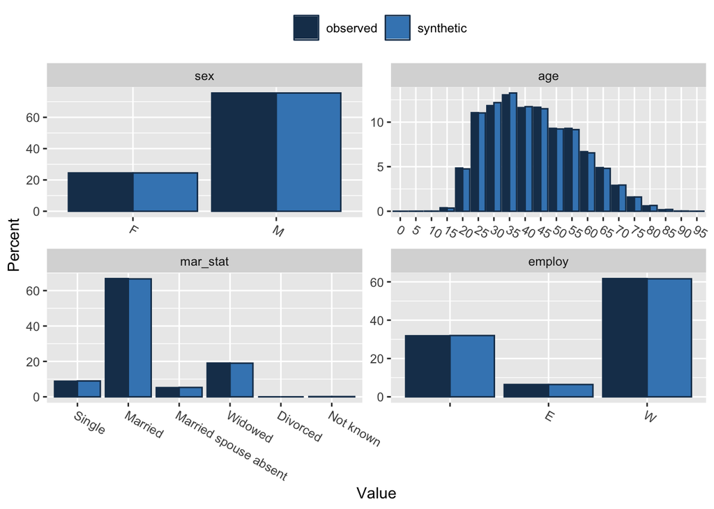

```
##
## Selected utility measures:
##           pMSE   S_pMSE df
## sex      0e+00 0.001057  1
## age      8e-06 2.679946  4
## mar_stat 3e-06 0.902129  4
## employ   0e+00 0.275986  2
```

```r
## We can also get visuals of multivariate distributions
multi.compare(synthetic_icem, simple_icem, var = "employ", by = c("sex", "mar_stat"))
```

```
##
## Plots of  employ  by  sex mar_stat
## Numbers in each plot (observed data):
##
##    mar_stat
## sex Single Married Married spouse absent Widowed Divorced Not known
##   F   4817     111                  3057   11969        0        85
##   M   2397   54574                  1209    3637        0        25
```

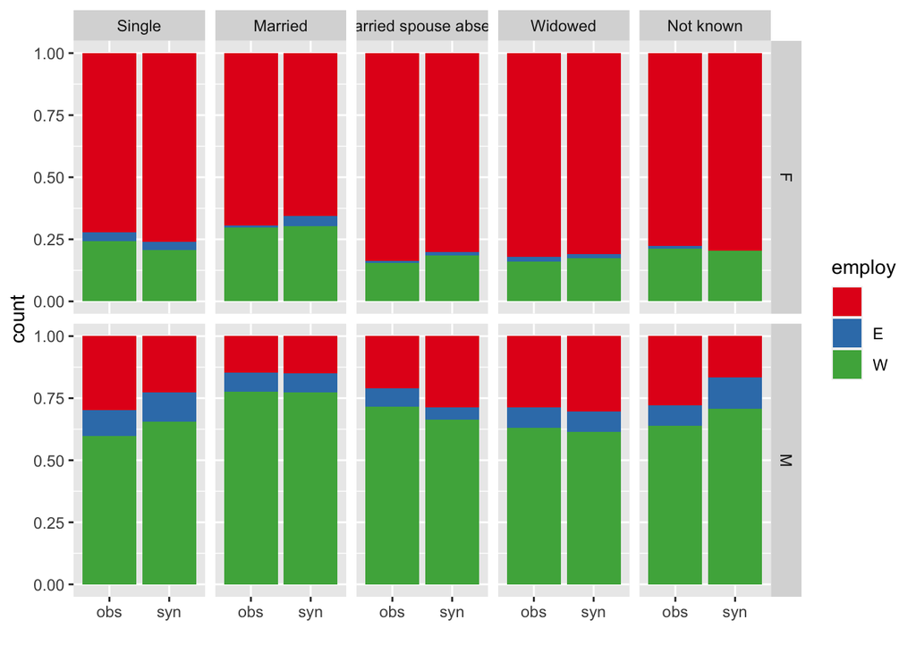

```r
## If we want to compare the fit of a linear model, we can use the following function
## outcome is whether individual is an employer (rather than a worker or unemployed)
icem_fit = glm(I(employ == 'E') ~ ., data = simple_icem, family = "binomial")
summary(icem_fit)
```

```
##
## Call:
## glm(formula = I(employ == "E") ~ ., family = "binomial", data = simple_icem)
##
## Deviance Residuals:
##     Min       1Q   Median       3Q      Max
## -0.7857  -0.4127  -0.3610  -0.2303   3.0780
##
## Coefficients:
##                                Estimate Std. Error z value Pr(>|z|)
## (Intercept)                   -4.410298   0.083317 -52.934  < 2e-16 ***
## sexM                           1.508476   0.064032  23.558  < 2e-16 ***
## age                            0.019837   0.001076  18.434  < 2e-16 ***
## mar_statMarried               -0.451020   0.058882  -7.660 1.86e-14 ***
## mar_statMarried spouse absent -0.794106   0.108954  -7.288 3.14e-13 ***
## mar_statWidowed               -0.686627   0.069123  -9.933  < 2e-16 ***
## mar_statNot known             -0.759932   0.593561  -1.280      0.2
## ---
## Signif. codes:  0 '***' 0.001 '**' 0.01 '*' 0.05 '.' 0.1 ' ' 1
##
## (Dispersion parameter for binomial family taken to be 1)
##
##     Null deviance: 39102  on 81880  degrees of freedom
## Residual deviance: 37700  on 81874  degrees of freedom
## AIC: 37714
##
## Number of Fisher Scoring iterations: 6
```

```r
# Now with synthetic data
## just main effects
synthetic_icem_fit = glm.synds(I(employ == 'E') ~ ., data = synthetic_icem, family = "binomial")

## we can get the estimated coefficients and standard errors for the synthetic model
summary(synthetic_icem_fit)
```

```
## Fit to synthetic data set with a single synthesis. Inference to coefficients
## and standard errors that would be obtained from the original data.
##
## Call:
## glm.synds(formula = I(employ == "E") ~ ., family = "binomial",
##     data = synthetic_icem)
##
## Combined estimates:
##                               xpct(Beta) xpct(se.Beta)  xpct(z) Pr(>|xpct(z)|)
## (Intercept)                   -4.4593580     0.0841671 -52.9822      < 2.2e-16
## sexM                           1.5172673     0.0645700  23.4980      < 2.2e-16
## age                            0.0205159     0.0010692  19.1877      < 2.2e-16
## mar_statMarried               -0.4400858     0.0575295  -7.6497      2.014e-14
## mar_statMarried spouse absent -0.8008475     0.1111373  -7.2059      5.765e-13
## mar_statWidowed               -0.7222087     0.0687033 -10.5120      < 2.2e-16
## mar_statNot known             -0.7172749     0.5928439  -1.2099         0.2263
##
## (Intercept)                   ***
## sexM                          ***
## age                           ***
## mar_statMarried               ***
## mar_statMarried spouse absent ***
## mar_statWidowed               ***
## mar_statNot known
## ---
## Signif. codes:  0 '***' 0.001 '**' 0.01 '*' 0.05 '.' 0.1 ' ' 1
```

```r
## we can compare the models visually and based on their point estimates and confidence intervals
## note that the confidential data, not the confidential glm object, is provided
compare(synthetic_icem_fit, simple_icem)
```

```
##
## Call used to fit models to the data:
## glm.synds(formula = I(employ == "E") ~ ., family = "binomial",
##     data = synthetic_icem)
##
## Differences between results based on synthetic and observed data:
##                                 Synthetic    Observed         Diff
## (Intercept)                   -4.45935803 -4.41029801 -0.049060020
## sexM                           1.51726730  1.50847619  0.008791104
## age                            0.02051587  0.01983692  0.000678957
## mar_statMarried               -0.44008579 -0.45102009  0.010934302
## mar_statMarried spouse absent -0.80084752 -0.79410639 -0.006741133
## mar_statWidowed               -0.72220872 -0.68662684 -0.035581880
## mar_statNot known             -0.71727489 -0.75993167  0.042656782
##                               Std. coef diff CI overlap
## (Intercept)                      -0.58883675  0.8497838
## sexM                              0.13729294  0.9649756
## age                               0.63094599  0.8390414
## mar_statMarried                   0.18569982  0.9526267
## mar_statMarried spouse absent    -0.06187138  0.9842162
## mar_statWidowed                  -0.51475891  0.8686815
## mar_statNot known                 0.07186594  0.9816665
##
## Measures for one synthesis and 7 coefficients
## Mean confidence interval overlap:  0.9201417
## Mean absolute std. coef diff:  0.3130388
##
## Mahalanobis distance ratio for lack-of-fit (target 1.0): 0.18
## Lack-of-fit test: 1.247968; p-value 0.9898 for test that synthesis model is compatible
## with a chi-squared test with 7 degrees of freedom.
##
## Confidence interval plot:
```

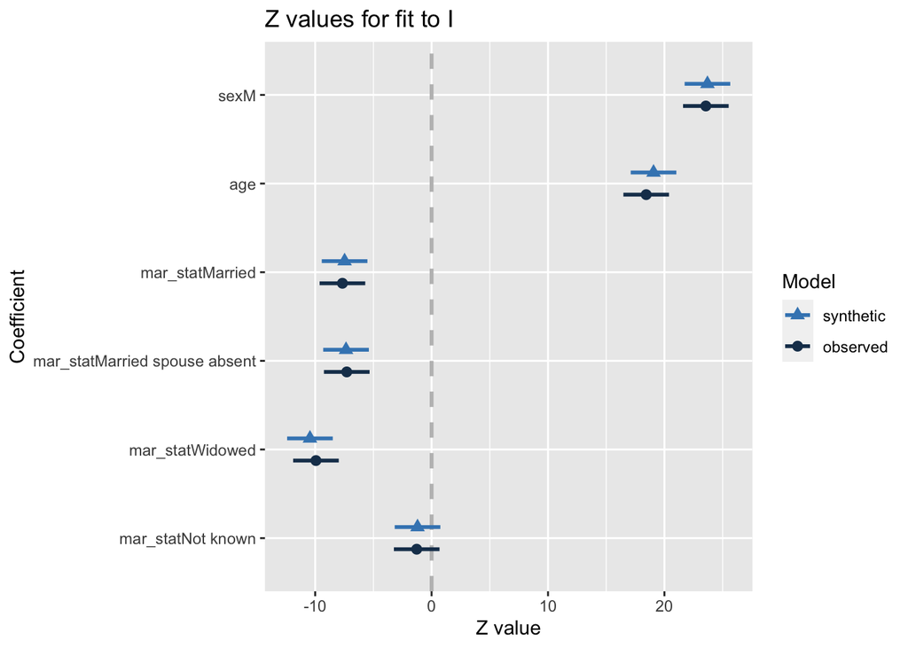

## Some Other Useful Synthesis Options

Lastly, we cover a couple common options that you may use when synthesizing data. First, creating new methods for variables that are constructed based on other variables. Second, increasing the number of levels of a factor variable.

```r
## we first create an object to say the type of synthesis for each variable
## default is CART for all variables
synthetic_method = rep('cart', ncol(icem_data))
## it needs to be named with the corresponding variable names
names(synthetic_method) = colnames(icem_data)
## but we change pperroom to be just hsize divided by totrooms for consistency in the data
synthetic_method[names(synthetic_method) == "pperroom"] <- "~I(hsize[!is.na(totrooms)] / totrooms[!is.na(totrooms)])"


## country of birth has a lot of levels, so we set the maxfaclevels to be larger enough
## note that this can slow down the synthesis, especially if using parametric models
synthetic_expanded_icem = syn(icem_data,
                              ## using our predefined methods object
                              method = synthetic_method,
                              maxfaclevels = 60)
```

```
##
## Method "cart" is not valid for a variable without predictors (sex)
## Method has been changed to "sample"
##
## Synthesis
## -----------
##  sex age mar_stat disability employ ctry_bth hsize totrooms pperroom
```

```r
synthetic_expanded_icem$method
```

```
##                                                      sex
##                                                 "sample"
##                                                      age
##                                                   "cart"
##                                                 mar_stat
##                                                   "cart"
##                                               disability
##                                                   "cart"
##                                                   employ
##                                                   "cart"
##                                                 ctry_bth
##                                                   "cart"
##                                                    hsize
##                                                   "cart"
##                                                 totrooms
##                                                   "cart"
##                                                 pperroom
## "~I(hsize[!is.na(totrooms)]/totrooms[!is.na(totrooms)])"
```

```r
## we can check that the synthesis rule worked as it should have
summary(synthetic_expanded_icem$syn$hsize / synthetic_expanded_icem$syn$totrooms -
          synthetic_expanded_icem$syn$pperroom)
```

```
##    Min. 1st Qu.  Median    Mean 3rd Qu.    Max.
##       0       0       0       0       0       0
```

```r
## we can look at the results for this expanded synthesis
compare(synthetic_expanded_icem, icem_data)
```

```
##
## Comparing percentages observed with synthetic
```

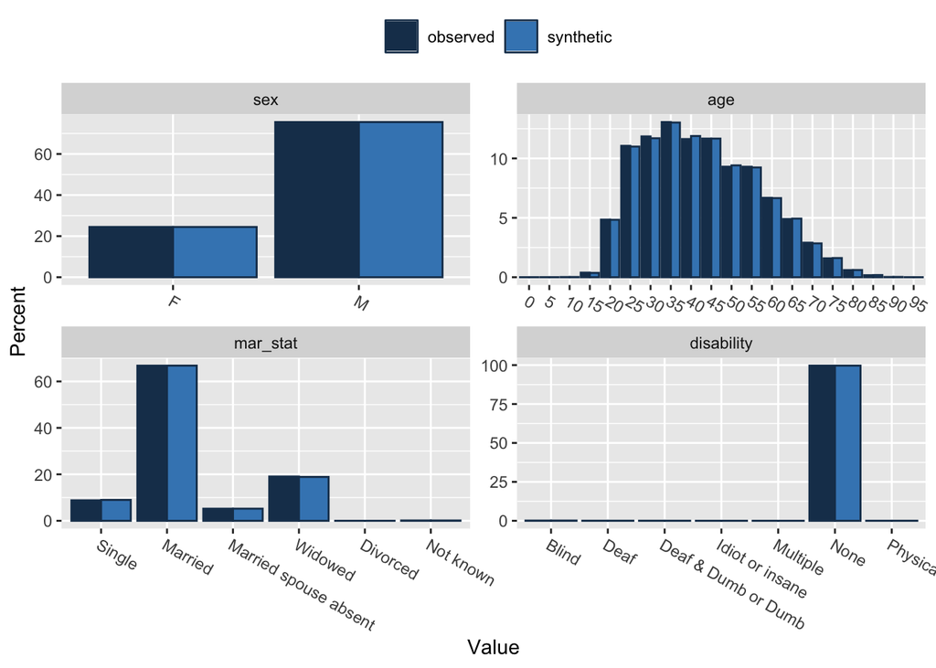

```
## Press return for next variable(s):
```

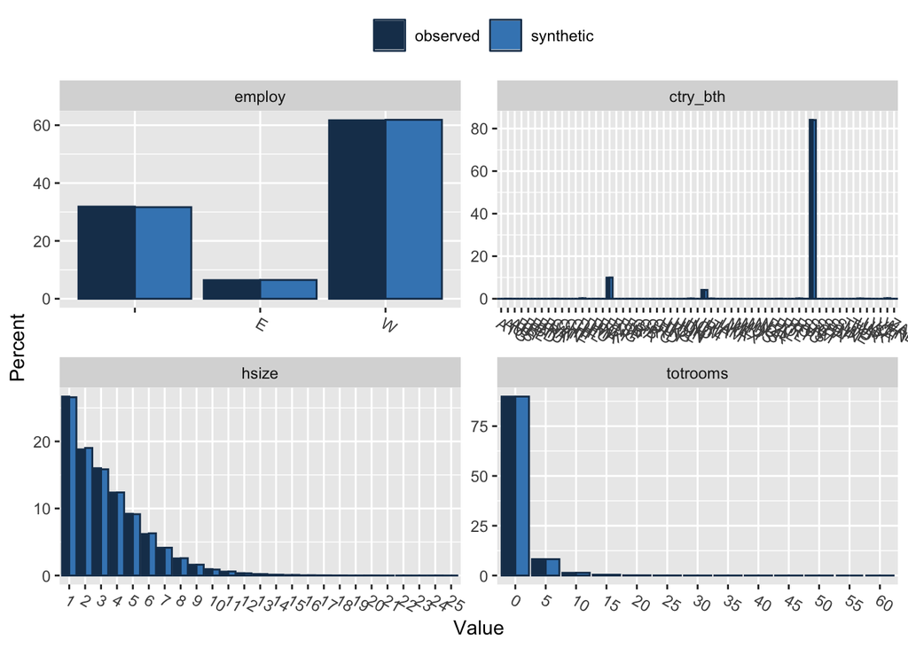

```
## Press return for next variable(s):
```

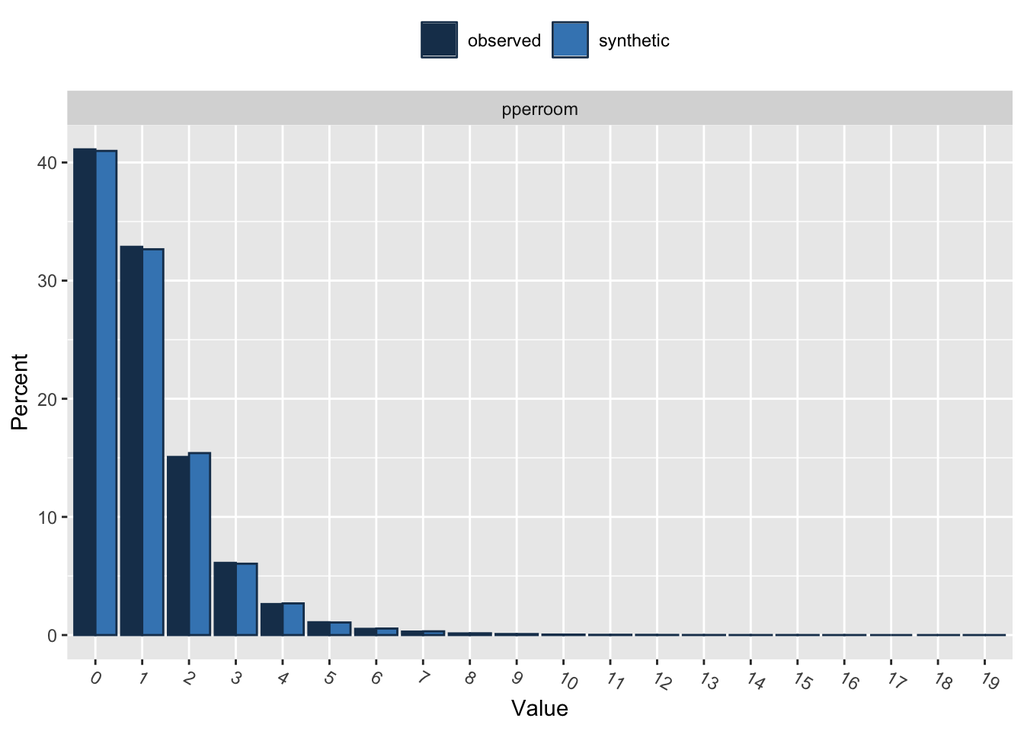

```
##
## Selected utility measures:
##             pMSE   S_pMSE df
## sex        0e+00 0.005353  1
## age        2e-06 0.584576  4
## mar_stat   3e-06 0.887945  5
## disability 3e-06 0.725925  6
## employ     1e-06 0.801802  2
## ctry_bth   5e-05 1.122960 58
## hsize      2e-06 0.727319  4
## totrooms   2e-06 0.759978  3
## pperroom   2e-06 0.652401  4
```

## Try One or More of the Following Yourself

1. Compare the synthetic data to the confidential data using the ‘multi.compare’ function or compare the fit of GLM models using the synthetic data and confidential data.
2. The following variables combine to make the hsize:
- nfamgteq15
- nfamlt15
- nboarders
- nlodgers
- nvisitors
- nkn
- nservants

Produce a synthetic data sets that synthesizes these variables and then creates the hsize variable, so that it is consistent.

3. The variables occlab1, occlab2, occlab3 are nested occupation labels. Synthesis them using the nested method (for example for occlab2 nested within occlab1 use the method ‘nested.occlab1’)
4. Or use your own data!